# Assignment 9

Manuela Giansante

2023-05-11

```r
library(fpp3)
library(data.table)
library(dplyr)
library(tidyr)
library(fable)
library(fabletools)
library(lmtest)
library(forecast)
library(cowplot)
library(aod)
library(stats) # arima.sim()
#library(simts) # for gen_gts()
library(vars)
```

## Question 3. Explain how multiple linear regression can be applied to time series, what are the model’s assumptions and what are the features commonly used. Explain both the goodness-of-fit test and the Wald test, by providing an example of such fitted model in the context of time series. Interpret the output.

A multiple linear regression model is used when there are more than one predictor variables, which need to be numerical. This means that the time series $y_t$’s behaviour through time is influenced by a number of inputs

$y_t=\beta_0+\beta_1x_1+\beta_2x_2+...+\beta_k x_{k,t}+\epsilon_t$

There are k predictors and the beta coefficients measure the marginal effect of the predictors on the time series $y_t$. The intercept measures the baseline value, so the value of $y_t$ if all other betas were 0. The interpretation of course depends on whether the model we are considering includes predictors that realistically will take value 0.

It can be used to either estimate trend and seasonality or the effects of exogenous factors on the dependent variable.

A guideline for predictors’ selection is that the predictors need to be “more predictable” than the predicted variable in order fr the model to be of any use.

### Assumptions

- For now we assume that the beta coefficients are fixed and unknown.
- The error term stores a random error or noise process that is normally independently and identically distributed with mean equal 0 and variance $\sigma^2$. The mean zero assumption, can be translated as the model on average makes does not make errors. They are symmetric. The variance of the residuals needs to be constant.

  The mean and variance assumption an be checked with a residuals vs. fitted plot.

  The normality of the residuals can be checked with a QQ plot, where normal data quantiles are plotted against normal theoretical quantiles.
- The errors are uncorrelated (independent) in their own process, otherwise it means there is still information in the data that could have been modelled.
- Moreover, the errors are not correlated with the predictors.

### Features

We said that the coefficients are unknown, they are estimated with the Least Squares Method. Their values are estimated so that the sum of the squared errors is minimized.

$\sum^T_{t=1}\epsilon^2_t=\sum^T_{t=1}(y_t-\beta_0-\beta_1x_{1,t}-\beta_2x_{2,t}-...-\beta_kx_{k,t})^2$

The interpretation of the coefficients of course is that for a unit change in the predictors we have a $\beta$ units change in the time series.

As features we can also include trend and seasonality. For seasonality, dummies are used, hence the first season is not estimated and it is used as a baseline, meaning that the $y$ in season 2 will be larger/smaller than $y$ in season 1 by the coefficient belonging to season 2 variable.

### Example

#### Model design

Say we want to fit a multiple linear regression on the CPI, which is the Consumer Price Index through which we measure Inflation. This index is defined as the change in the prices of a basket of selected goods and services, measured period to period.

We first source our data from the `global_economy`dataset, which stores yearly data up to 2017 and also contains other indices as well. The first indeces we would like to consider are Imports and Exports. We briefly explain why we are considering these two indexes and their dynamics which inflation. A supposed increase in inflation within a domestic economy should lead to a decrease in exports (ceteris paribus) as exports products have become less attractive to foreign buyers as these goods are now more expensive. These domestic good are now less requested, the domestic currency will see a decrease in its demand, therefore lowering the exchange rate. This potentially brings a dual result: The lowered exchange rate now makes the domestic goods more competitive on the international market, hence exports in a later period might increase again. The second eventuality is that there might be a case of imported inflation, meaning that imported raw materials are now more expensive and domestic products that use those raw materials will result to have inflated prices. Considering this piece of very basic macro-economic theory, we start importing the data and plotting the considered series.

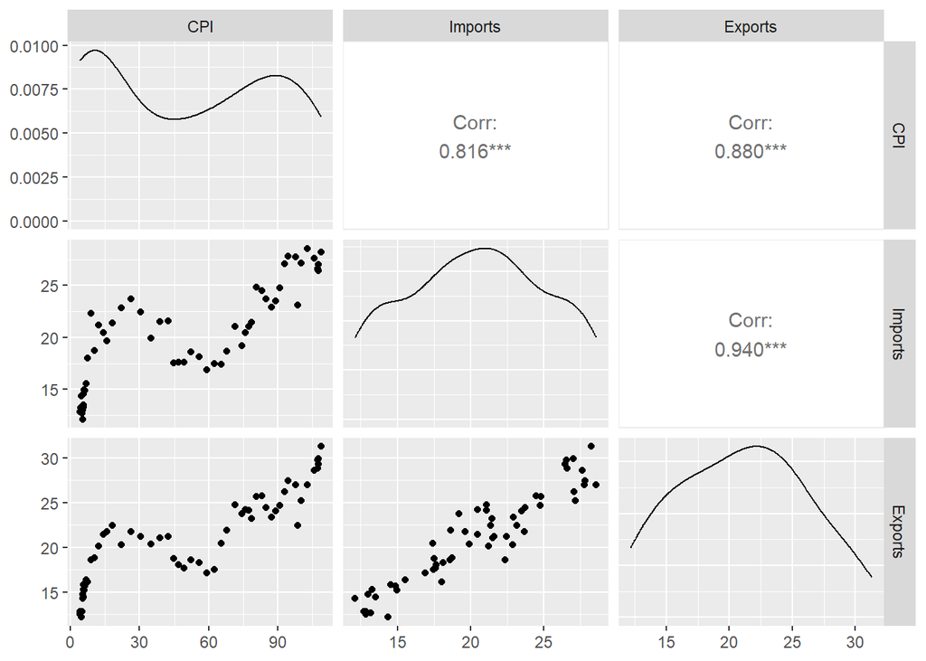

```r
# import the data
data<- global_economy %>%filter(Country == "Italy")

# CPI, Imports and Exports
data%>%
  GGally::ggpairs(columns=c(6:8))
```

We observe that the relationship between CPI and the Imports and Exports indices is not necessarily linear. We keep this in mind for the modelling of the regression model. Imports and Exports do show high correlation with CPI.

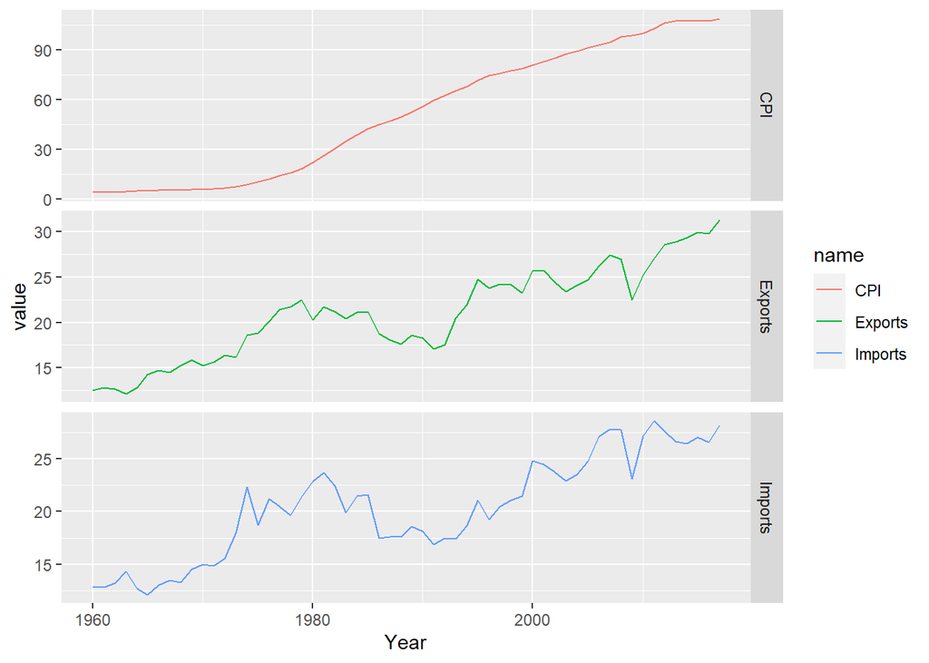

```r
# We plot the three series
# pivot_longer() transforms the data from wide to long format
data %>%
  dplyr::select(CPI,Imports, Exports)%>%
  tidyr::pivot_longer(-Year)%>%
  ggplot(aes(Year, value, colour = name))+
  geom_line() + facet_grid(name ~ ., scales = "free_y")
```

All three indexes increase over time, this is not necessarily specific to Italy but rather a global trend. There is no seasonality to observe because the data is yearly. CPI does not seem to report any major cycles, which makes sense given CPI is observed as a growth rate.

We start by fitting a simple model only with Import and Exports:

```r
# we fit the data
fit <- data %>%
  model(tslm = TSLM(CPI ~ Imports + Exports))
report(fit)
```

```
## Series: CPI
## Model: TSLM
##
## Residuals:
##     Min      1Q  Median      3Q     Max
## -42.756 -10.130   1.705  11.620  38.535
##
## Coefficients:
##             Estimate Std. Error t value Pr(>|t|)
## (Intercept) -86.5192    10.6528  -8.122 5.53e-11 ***
## Imports      -0.7569     1.4766  -0.513     0.61
## Exports       7.2961     1.4037   5.198 3.05e-06 ***
## ---
## Signif. codes:  0 '***' 0.001 '**' 0.01 '*' 0.05 '.' 0.1 ' ' 1
##
## Residual standard error: 18.44 on 55 degrees of freedom
## Multiple R-squared: 0.7758,  Adjusted R-squared: 0.7676
## F-statistic: 95.14 on 2 and 55 DF, p-value: < 2.22e-16
```

We notice that Imports do not result significant, this probably is due to the modelling choices. The Adjusted R^2 is of 76%.

```r
# we fit the data with GDP as well
fit2 <- data %>%
  model(tslm = TSLM(CPI ~ Imports + Exports+ GDP))
report(fit2)
```

```
## Series: CPI
## Model: TSLM
##
## Residuals:
##      Min       1Q   Median       3Q      Max
## -16.5520  -5.2545  -0.1409   4.0901  15.9032
##
## Coefficients:
##               Estimate Std. Error t value Pr(>|t|)
## (Intercept) -1.528e+01  5.951e+00  -2.567  0.01306 *
## Imports     -2.050e+00  5.935e-01  -3.454  0.00108 **
## Exports      3.360e+00  6.051e-01   5.553 8.78e-07 ***
## GDP          4.009e-11  2.346e-12  17.089  < 2e-16 ***
## ---
## Signif. codes:  0 '***' 0.001 '**' 0.01 '*' 0.05 '.' 0.1 ' ' 1
##
## Residual standard error: 7.35 on 54 degrees of freedom
## Multiple R-squared: 0.965,   Adjusted R-squared: 0.9631
## F-statistic: 496.4 on 3 and 54 DF, p-value: < 2.22e-16
```

While using this we are aware that these data might not have been processed in the same way, therefore we include it in our model, to test the theoretical assumptions made in the beginning of the analysis.

```
## Plot variable not specified, automatically selected `.vars = Value`
```

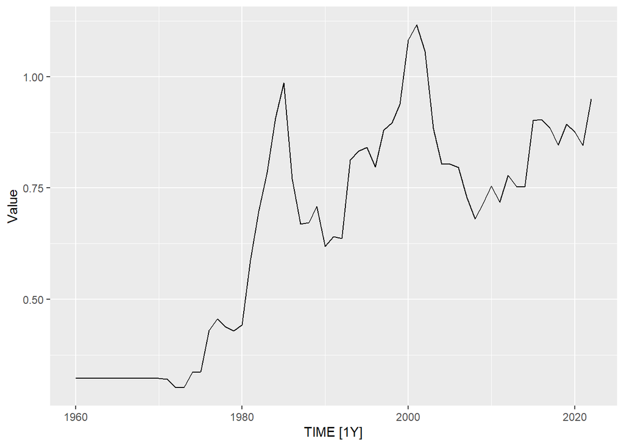

```r
# Import exchange rate data
EX<-fread("DP_LIVE_13052023204101853.csv")%>% filter(LOCATION=="ITA") %>% as_tsibble(index=TIME)

# plot exchange rate
autoplot(EX)
```

```r
# Merge the two data sets
# Including only data until 2017
data_2<-dplyr::bind_cols(data,EX[c(1:58),7])

# We rename the column that stores the exchange rate
data_2$Exchange_Rate<-data_2$Value
data_2<- data_2 %>% dplyr::select(Year, CPI, Imports, Exports, Exchange_Rate, GDP)

#Fit the model
fit3 <- data_2 %>%
  model(tslm = TSLM(CPI ~ Imports + Exports + Exchange_Rate))
report(fit3)
```

```
## Series: CPI
## Model: TSLM
##
## Residuals:
##     Min      1Q  Median      3Q     Max
## -30.415  -7.507   1.437  10.568  35.791
##
## Coefficients:
##               Estimate Std. Error t value Pr(>|t|)
## (Intercept)   -80.3157     9.3370  -8.602 1.07e-11 ***
## Imports         0.1933     1.2975   0.149  0.88212
## Exports         4.2749     1.3973   3.059  0.00345 **
## Exchange_Rate  59.2288    13.4918   4.390 5.31e-05 ***
## ---
## Signif. codes:  0 '***' 0.001 '**' 0.01 '*' 0.05 '.' 0.1 ' ' 1
##
## Residual standard error: 15.97 on 54 degrees of freedom
## Multiple R-squared: 0.8347,  Adjusted R-squared: 0.8256
## F-statistic: 90.92 on 3 and 54 DF, p-value: < 2.22e-16
```

The Exchange rate time series does convey the same growing trend that we observed in the other considered variables. The Marginal Effect of the exchange rate is highly significant and the model has increased in performance. We run one last trial by including the country’s GDP.

```r
# fit the model
fit4 <- data_2 %>%
  model(TSLM(CPI ~ Imports + Exports + Exchange_Rate + GDP))
report(fit4)
```

```
## Series: CPI
## Model: TSLM
##
## Residuals:
##     Min      1Q  Median      3Q     Max
## -8.7145 -1.3746 -0.2915  2.1179  7.1788
##
## Coefficients:
##                 Estimate Std. Error t value Pr(>|t|)
## (Intercept)   -1.582e+01  2.555e+00  -6.190 9.02e-08 ***
## Imports       -1.288e+00  2.595e-01  -4.962 7.60e-06 ***
## Exports        1.494e+00  2.864e-01   5.216 3.09e-06 ***
## Exchange_Rate  4.194e+01  2.707e+00  15.491  < 2e-16 ***
## GDP            3.732e-11  1.023e-12  36.479  < 2e-16 ***
## ---
## Signif. codes:  0 '***' 0.001 '**' 0.01 '*' 0.05 '.' 0.1 ' ' 1
##
## Residual standard error: 3.156 on 53 degrees of freedom
## Multiple R-squared: 0.9937,  Adjusted R-squared: 0.9932
## F-statistic:  2080 on 4 and 53 DF, p-value: < 2.22e-16
```

After adding the GDP as predictor the whole model has gained in significance and the adjusted R^2 has increased significantly. The imports coefficient is negative, whilst Exports result to have a positive impact on CPI, which is not necessarily in line with the theory we devoloped our hypothesis on. Exchange rate is positive which seems reasonable. You may have noticed how whilst we were considering the performance of our model we mentioned two things, the Adjusted R^2 and whether a coefficient resulted significant or not.

### Goodness of fit test

#### R^2

In our case we have not used cross-validation, we are judging the model performance in-sample. The Goodness of fit of a linear model model is measured by R^2 and adjusted R^2.

$R^2 = \frac{\sum(\hat{y_t}-\bar{y})^2}{\sum(y_t-\hat{y})^2}$

$R^2adj= \frac{T-1}{T-P-1}\times{R^2}$

The numerator is the squared correlation between the predicted values and the actual values. Hence, the statistic takes values from 0 to 1,and it measures how much of the variation in $y_t$ is accounted for by the predictors. The are limits to the use of this values for evaluation of the model’s performance. Whether we use the regular R^2 or the adjusted measure (R^2 adjusted penalises the amount of predictors used), this measure will still grow as we add predictors, so we must be parsimonious in the predictors selection.

```r
# model with GDP
glance(fit2) %>% dplyr::select(adj_r_squared, AIC, AICc,BIC)
```

```
## # A tibble: 1 x 4
##   adj_r_squared   AIC  AICc   BIC
##           <dbl> <dbl> <dbl> <dbl>
## 1         0.963  237.  238.  248.
```

```r
# model with Exchange rate
glance(fit3) %>% dplyr::select(adj_r_squared, AIC, AICc,BIC)
```

```
## # A tibble: 1 x 4
##   adj_r_squared   AIC  AICc   BIC
##           <dbl> <dbl> <dbl> <dbl>
## 1         0.826  327.  328.  338.
```

```r
# model with Exchange Rate and GDP
glance(fit4) %>% dplyr::select(adj_r_squared, AIC, AICc,BIC)
```

```
## # A tibble: 1 x 4
##   adj_r_squared   AIC  AICc   BIC
##           <dbl> <dbl> <dbl> <dbl>
## 1         0.993  140.  142.  152.
```

When looking at the adj_R^2 values for these three models, we see how the one with more predictors does in fact have a higher percentage of explained variance, we can also notice how adding the exchange rate to the starting model `fit` did yield some results, but the true step up in our case was including the Gross Domestic Product. In this case one should be very careful and on the look out for **spurious correlation**. GDP and Inflation are highly correlated, and this per se is not a problem, the issue here is that we should reflect on the relationships among the predictors.

Bayesian Information Criteria will always favour the simpler models, it penalises the number of features more heavily than AIC does.

In our case, perfect correlation between predictors was not present, regardless it is something that should be taken into account.

A deeper discussion on predictor selection within this theoretical field is not really the goal of this exercise, but if we were conducting a research on Inflation forecast we should meditate more on the variables included.

#### k-Cross validation

The dataset if randomly split into k different disjoint subsets. One of this splits will be selected, the model fitted on the rest of the data, the subset is predicted and then the prediction error is computed. This process is repeated for all k subsets, and the average error is computed.

K needs to be chosen according to sample size. Moreover, we need to consider the possibility of data having a trend, this will make the randomly selected splits not really comparable. Our data does have trend, which is why have not run CV so far.

We can try and run a Generalised Cross-Validation where the model is fitted only once.

```r
# we re-run the model with the lm() function
#for format requirements
# the estimation is the same
model_complete<- lm(CPI ~ Imports + Exports + Exchange_Rate + GDP, data = data_2)

model2<- lm(CPI ~ Imports + Exports + GDP, data = data_2)

# Generalized Cross-Validation
CV(model_complete)
```

```
##          CV         AIC        AICc         BIC       AdjR2
##  11.3644934 140.0761364 141.7231952 152.4387945   0.9931924
```

```r
CV(model2)
```

```
##          CV         AIC        AICc         BIC       AdjR2
##  57.1825253 237.2459070 238.3997532 247.5481221   0.9630646
```

The lowest CV value if achieved by the complete model.

#### Fitted vs. Actual Values

Another important method that has to be considered is the graphical representation of the fitted values vs the true data.

The models with higher R^2 values will see the point being closer to the diagonal line.

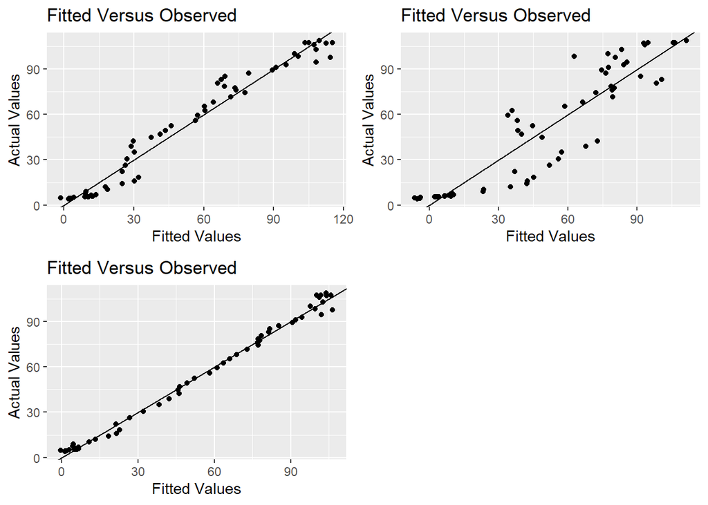

```r
# fitted model 2
fvst_2<-augment(fit2) %>%
  ggplot(aes(x = .fitted, y = CPI)) +
  geom_point() +
  labs(
    y = "Actual Values",
    x = "Fitted Values",
    title = "Fitted Versus Observed"
  ) + geom_abline(intercept = 0, slope = 1)

#fitted model 3
fvst_3<-augment(fit3) %>%
  ggplot(aes(x = .fitted, y = CPI)) +
  geom_point() +
  labs(
    y = "Actual Values",
    x = "Fitted Values",
    title = "Fitted Versus Observed"
  ) + geom_abline(intercept = 0, slope = 1)

# fitted model 4
fvst_4<-augment(fit4) %>%
  ggplot(aes(x = .fitted, y = CPI)) +
  geom_point() +
  labs(
    y = "Actual Values",
    x = "Fitted Values",
    title = "Fitted Versus Observed"
  ) + geom_abline(intercept = 0, slope = 1)

# organised printing
plot_grid(fvst_2,fvst_3, fvst_4)
```

The plot allows us to observe if the fit of the model if good uniformly across the data, meaning the model is able to handle more extreme values. In our case the best performance is achieved by model 4.

### Wald test

We have discussed the global fit of the model, and we also discussed how we should be careful when selecting the predictors.

A way of doing this is performing a Wald test on the model coefficients. The test’s null hypothesis that the selected set of predictors are equal to 0.

```r
wald.test(Sigma = vcov(model_complete), b = coef(model_complete), Terms = 1:4)
```

```
## Wald test:
## ----------
##
## Chi-squared test:
## X2 = 503.7, df = 4, P(> X2) = 0.0
```

The p-value is less than 0.05, therefore we can reject the null hypothesis. This result is coherent with the fact that our coefficients were al significant.

### Considerations

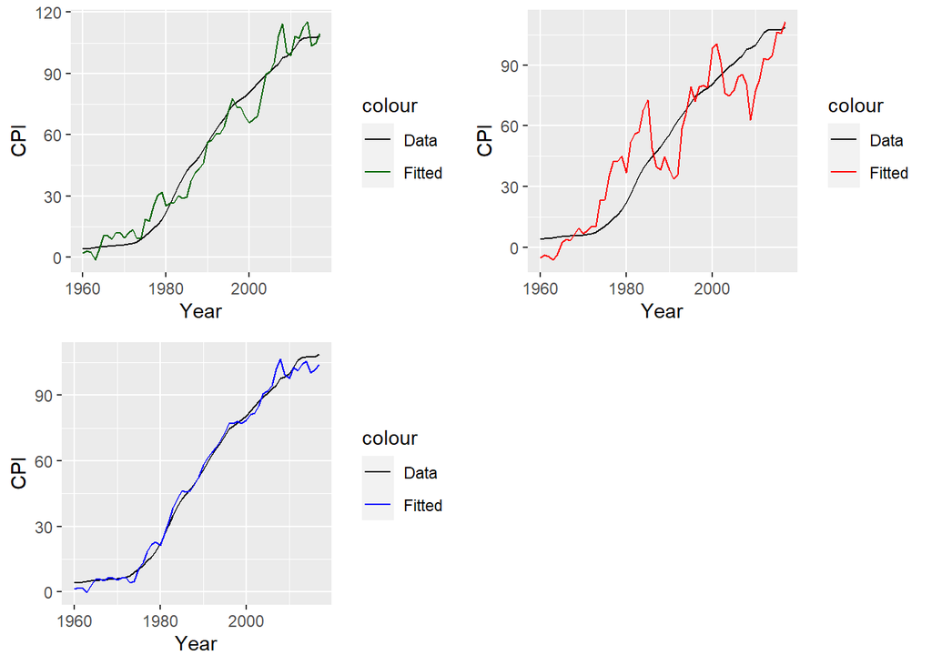

```r
# plot of model with gdp
gr_2<- augment(fit2)%>%
  ggplot(aes(x = Year)) +
  geom_line(aes(y = CPI, colour = "Data")) +
  geom_line(aes(y = .fitted, colour = "Fitted")) +
  scale_colour_manual(
    values = c(Data = "black", Fitted = "darkgreen")
  )
# plot of model with Exchange rate
gr_3<-augment(fit3)%>%
  ggplot(aes(x = Year)) +
  geom_line(aes(y = CPI, colour = "Data")) +
  geom_line(aes(y = .fitted, colour = "Fitted")) +
  scale_colour_manual(
    values = c(Data = "black", Fitted = "red")
  )

# model with GDP and Exchange rate
gr_4<-augment(fit4)%>%
  ggplot(aes(x = Year)) +
  geom_line(aes(y = CPI, colour = "Data")) +
  geom_line(aes(y = .fitted, colour = "Fitted")) +
  scale_colour_manual(
    values = c(Data = "black", Fitted = "blue")
  )

plot_grid(gr_2, gr_3, gr_4)
```

The above graphics show the fits of our models. Especially, in fit 3 we see the strong influence of the Exchange Rate variable on the fitted model. Therefore, including GDP seems to bring a closer fit.

#### Residuals Diagnostics

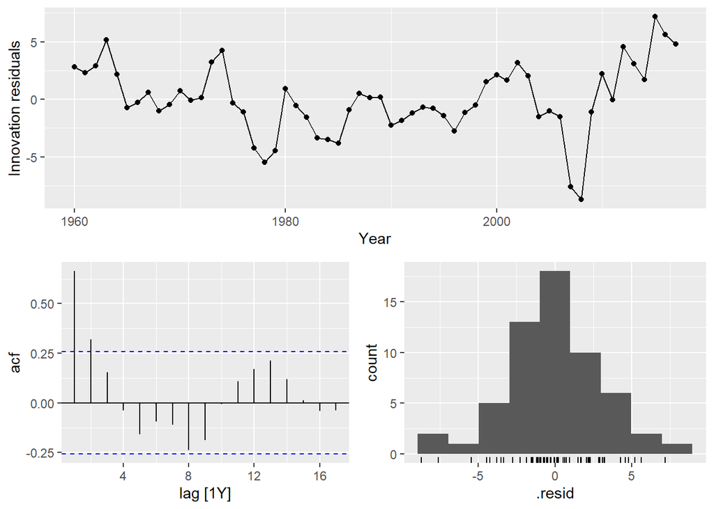

```r
gg_tsresiduals(fit4)
```

The histogram is not perfectly symmetric, this might influence the PI.

#### Breusch-Godfrey Tetst

Testing is there is serial correlation for higher order lags. We check for lag 2. We use the lm() object corresponding to `fit4`.

```r
bgtest(model_complete, order=2)
```

```
##
##  Breusch-Godfrey test for serial correlation of order up to 2
##
## data:  model_complete
## LM test = 28.356, df = 2, p-value = 6.959e-07
```

### Forecast

In this case to produce a forecast, we need to forecast by scenarios. Meaning that we will produce a forecast fo $y_T$ but to do so we need to specify the values of our predictors. This means that we can produce multiple predictions depending on the hypothesised level of the predictors.

The scenarios we consider is an average case, where the predictors take their mean values, and a slight increase from the latest data points.

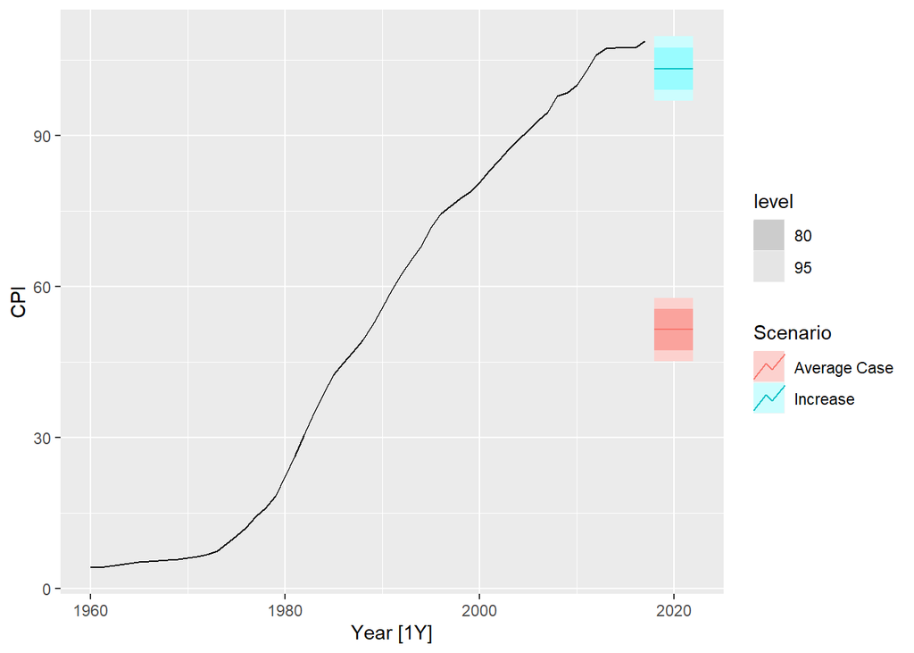

```r
# designing future scenarios
future_scenarios <- scenarios(
  "Average Case" = new_data(data_2, 5) %>%
    mutate(Imports=mean(data_2$Imports), Exports=mean(data_2$Exports), Exchange_Rate=mean(data_2$Exchange_Rate), GDP=mean(data_2$GDP)),
  "Increase"= new_data(data_2, 5) %>%
    mutate(Imports=29, Exports=30, Exchange_Rate=0.89, GDP=1.99e+12),
  names_to = "Scenario")

# fabricate forecast
fc <- fabletools::forecast(fit4, new_data = future_scenarios)

#plot the scenarios
data_2 %>%
  autoplot(CPI) +
  autolayer(fc)
```

What this exercise tells us is that considering averages would be totally inappropriate, because that would imply a great downwards shock. What the latter scenario does is implement a slight increase in all instances, but this scenario is much more realistic because it supposes more “in the norm” behaviour of all variables.

### Further considerations on features

The data we are using is yearly so we cannot observe any seasonality, still we can include trend in our model, integrating the exogenous variables with trend information from past observations. This of course might lead to over fitting, so as stated before we might want to be parsimonious with our selection of variables.

When modelling the trend we could also introduce a dummy signalling an event. Within the realm of the data we have we could maybe code the introduction of a international trade policy, a raise in tariffs or within the Italian context a ECB decision or a spokes person public declaration (i.e. Mario Draghi’s “Whatever it takes” in 2012 did influence the behaviour of the markets).

```r
fitx<- data_2 %>%
  model(TSLM(CPI ~ trend()+Imports + Exports ))
report(fitx)
```

```
## Series: CPI
## Model: TSLM
##
## Residuals:
##    Min     1Q Median     3Q    Max
## -8.626 -4.247 -0.105  3.597 15.480
##
## Coefficients:
##             Estimate Std. Error t value Pr(>|t|)
## (Intercept)   8.6139     5.1890   1.660   0.1027
## trend()       2.6974     0.1153  23.390   <2e-16 ***
## Imports      -1.0601     0.4468  -2.372   0.0213 *
## Exports      -0.7208     0.5457  -1.321   0.1921
## ---
## Signif. codes:  0 '***' 0.001 '**' 0.01 '*' 0.05 '.' 0.1 ' ' 1
##
## Residual standard error: 5.577 on 54 degrees of freedom
## Multiple R-squared: 0.9799,  Adjusted R-squared: 0.9787
## F-statistic: 875.6 on 3 and 54 DF, p-value: < 2.22e-16
```

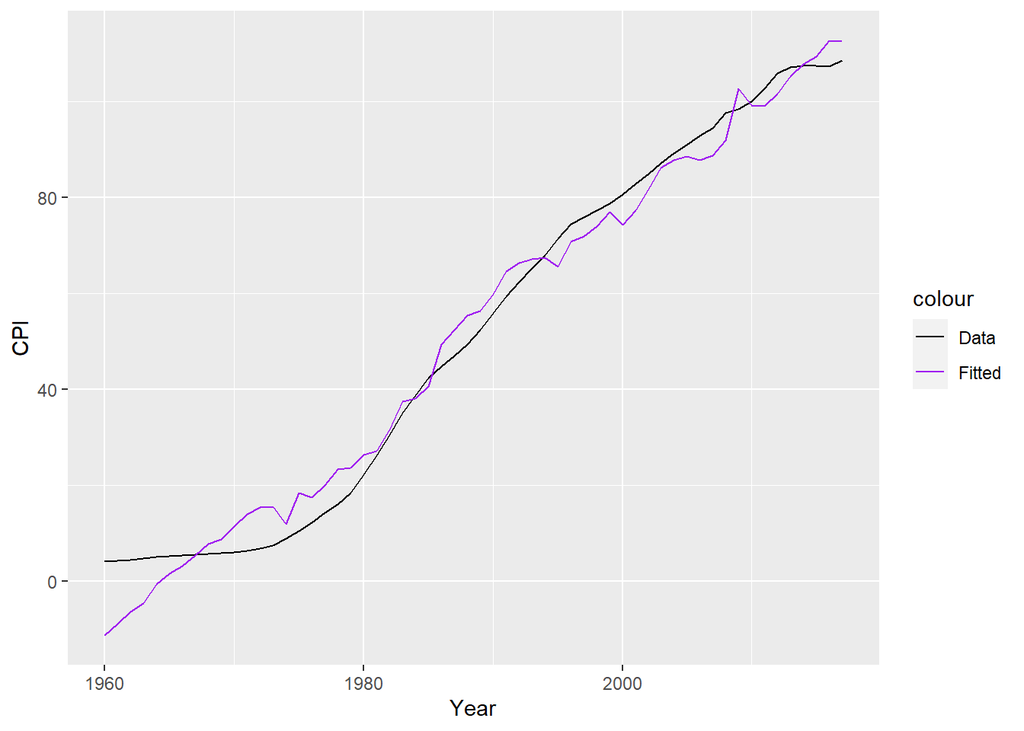

```r
augment(fitx)%>%
  ggplot(aes(x = Year)) +
  geom_line(aes(y = CPI, colour = "Data")) +
  geom_line(aes(y = .fitted, colour = "Fitted")) +
  scale_colour_manual(
    values = c(Data = "black", Fitted = "Purple")
  )
```

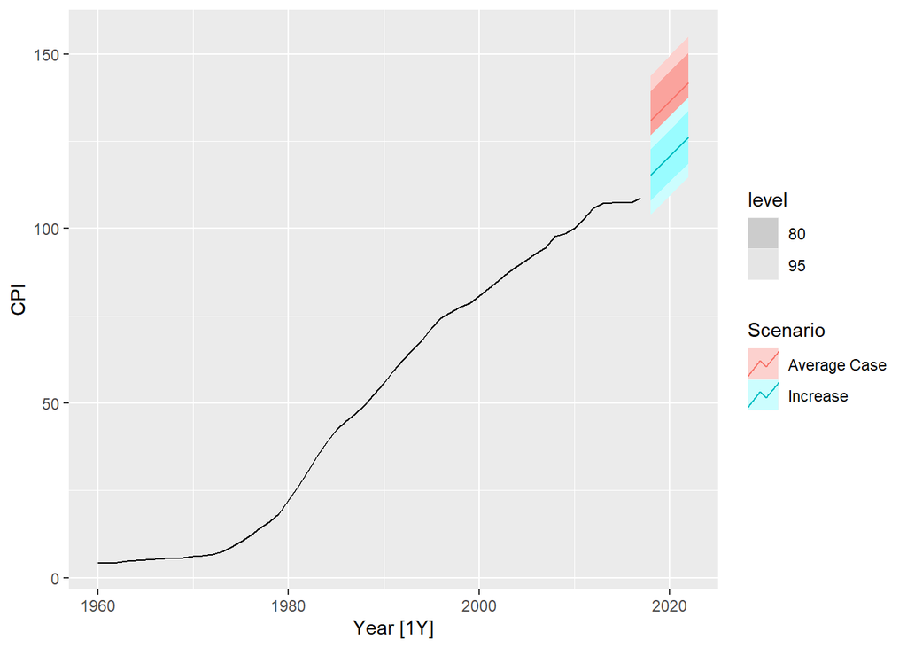

```r
fc2 <- fabletools::forecast(fitx, new_data = future_scenarios)

#plot the scenarios
data_2 %>%
  autoplot(CPI) +
  autolayer(fc2)
```

Something that could be done to run a VAR where the regressions run are two. We could consider regressing CPI and Exports on each others’ and their own past observations. This would be more useful to grasp whether the two move together.

### Vector Autoregressive Model

So far we have regressed CPI on other time series and its trend, but maybe regressing the series on itself and on past lag of the Exports series could be a way to explore their relationship. To understand if they move together.

We try to model CPI and exports, the distinction between exogenous and non exogenous variables are not well distinguished. In our introductory discussion we have seen how the model considers movements of the two through time. VAR assumes for these two series to be stationary, we have seen they have upwards trend, we need to remedy that.

Regarding the residuals it also assumes they are non serially correlated, normally distributed and Homoskedastic.

```
## Plot variable not specified, automatically selected `.vars = cpi_stat`
```

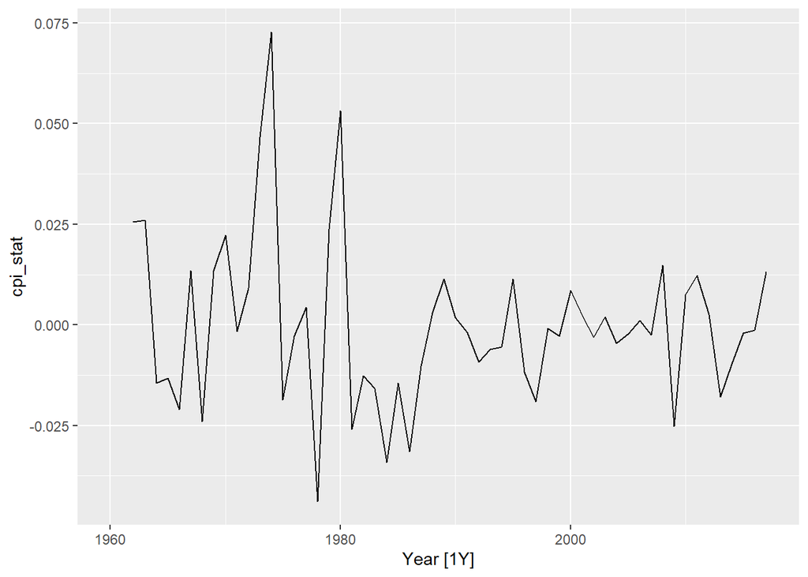

```r
data_2 %>% dplyr::select(CPI)%>% transmute("cpi_stat"=difference(difference(log(CPI))))%>% autoplot()
```

```r
data_2 %>% dplyr::select(CPI)%>% transmute("cpi_stat"=difference(difference(log(CPI))))%>% features(cpi_stat, unitroot_kpss)
```

```
## # A tibble: 1 x 2
##   kpss_stat kpss_pvalue
##       <dbl>       <dbl>
## 1     0.157         0.1
```

```
## Plot variable not specified, automatically selected `.vars = exp_stat`
```

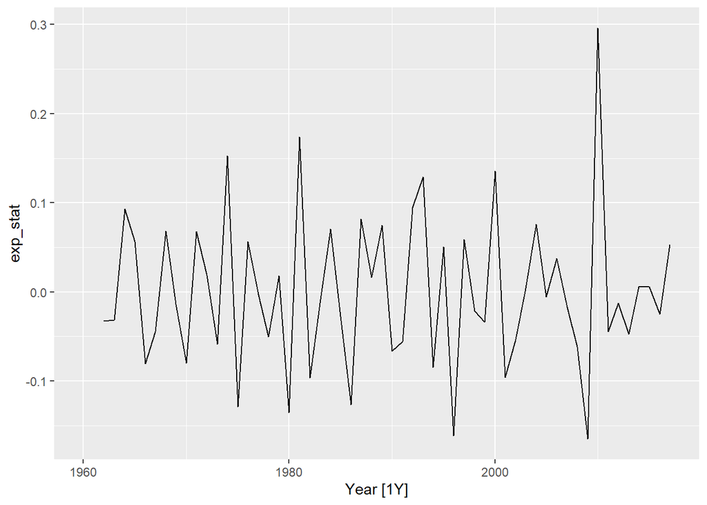

```r
data_2 %>% dplyr::select(Exports)%>% transmute("exp_stat"=difference(difference(log(Exports))))%>% autoplot()
```

```r
data_2 %>% dplyr::select(Exports)%>% transmute("exp_stat"=difference(difference(log(Exports))))%>% features(exp_stat, unitroot_kpss)
```

```
## # A tibble: 1 x 2
##   kpss_stat kpss_pvalue
##       <dbl>       <dbl>
## 1    0.0389         0.1
```

```r
CPI<- data_2 %>% dplyr::select(CPI)%>% transmute("cpi_stat"=difference(difference(log(CPI))))

Exports<- data_2 %>% dplyr::select(Exports)%>% transmute("exp_stat"=difference(difference(log(Exports))))

# drop the NAs
CPI<-CPI[-c(1:2),]
Exports<- Exports[-c(1:2),]

var_df<-dplyr::bind_cols(CPI[,2],Exports[,2])
```

We can finally fit the model:

```r
# we use the varselect function to know up to what lag it is best to regress
VARselect(var_df)
```

```
## $selection
## AIC(n)  HQ(n)  SC(n) FPE(n)
##      6      4      1      4
##
## $criteria
##                    1             2             3             4             5
## AIC(n) -1.263257e+01 -1.260697e+01 -1.264370e+01 -1.281486e+01 -1.275560e+01
## HQ(n)  -1.254322e+01 -1.245805e+01 -1.243521e+01 -1.254680e+01 -1.242798e+01
## SC(n)  -1.239405e+01 -1.220944e+01 -1.208715e+01 -1.209930e+01 -1.188104e+01
## FPE(n)  3.265166e-06  3.354382e-06  3.243258e-06  2.748008e-06  2.941126e-06
##                    6             7             8             9            10
## AIC(n) -1.281702e+01 -1.269888e+01 -1.277880e+01 -1.267279e+01 -1.265239e+01
## HQ(n)  -1.242983e+01 -1.225213e+01 -1.227248e+01 -1.210690e+01 -1.202694e+01
## SC(n)  -1.178344e+01 -1.150629e+01 -1.142720e+01 -1.116217e+01 -1.098276e+01
## FPE(n)  2.801400e-06  3.209303e-06  3.034738e-06  3.482149e-06  3.701231e-06
```

```r
# we fit the model and keep a more conservative approach
var<-VAR(var_df,4,type="none")
summary(var)
```

```
##
## VAR Estimation Results:
## =========================
## Endogenous variables: cpi_stat, exp_stat
## Deterministic variables: none
## Sample size: 52
## Log Likelihood: 204.592
## Roots of the characteristic polynomial:
## 0.7926 0.7926 0.7858 0.7858 0.7836 0.7836 0.6904 0.6904
## Call:
## VAR(y = var_df, p = 4, type = "none")
##
##
## Estimation results for equation cpi_stat:
## =========================================
## cpi_stat = cpi_stat.l1 + exp_stat.l1 + cpi_stat.l2 + exp_stat.l2 + cpi_stat.l3 + exp_stat.l3 + cpi_stat.l4 + exp_stat.l4
##
##             Estimate Std. Error t value Pr(>|t|)
## cpi_stat.l1  0.23357    0.14698   1.589    0.119
## exp_stat.l1 -0.03148    0.04186  -0.752    0.456
## cpi_stat.l2 -0.17360    0.14626  -1.187    0.242
## exp_stat.l2 -0.01499    0.04677  -0.321    0.750
## cpi_stat.l3  0.24240    0.14795   1.638    0.108
## exp_stat.l3 -0.04496    0.04667  -0.963    0.341
## cpi_stat.l4 -0.23583    0.14647  -1.610    0.115
## exp_stat.l4 -0.06014    0.03923  -1.533    0.132
##
##
## Residual standard error: 0.02028 on 44 degrees of freedom
## Multiple R-Squared: 0.1548,  Adjusted R-squared: 0.001177
## F-statistic: 1.008 on 8 and 44 DF,  p-value: 0.4442
##
##
## Estimation results for equation exp_stat:
## =========================================
## exp_stat = cpi_stat.l1 + exp_stat.l1 + cpi_stat.l2 + exp_stat.l2 + cpi_stat.l3 + exp_stat.l3 + cpi_stat.l4 + exp_stat.l4
##
##             Estimate Std. Error t value Pr(>|t|)
## cpi_stat.l1  -0.2956     0.5005  -0.591 0.557843
## exp_stat.l1  -0.6944     0.1425  -4.872 1.47e-05 ***
```

[output cut: 10 more lines]

```
## Residual standard error: 0.06906 on 44 degrees of freedom
## Multiple R-Squared: 0.4814,  Adjusted R-squared: 0.3871
## F-statistic: 5.105 on 8 and 44 DF,  p-value: 0.0001577
##
##
##
## Covariance matrix of residuals:
##          cpi_stat exp_stat
## cpi_stat 0.000411 0.000360
## exp_stat 0.000360 0.004769
##
## Correlation matrix of residuals:
##          cpi_stat exp_stat
## cpi_stat   1.0000   0.2572
## exp_stat   0.2572   1.0000
```

None of the coefficients we are interested in (the non-autoregressive terms) turn out significant enough to be considered valuable in our estimation.

For completion we run a Impulse Response Analysis, where the series react to a simulated shock and we observe the reaction, if they do not react than probably this approach for these two time series was not appropriate. We consider a shock in exports and the consequential response of Consumer Price Index, within a 5 steps ahead time frame.

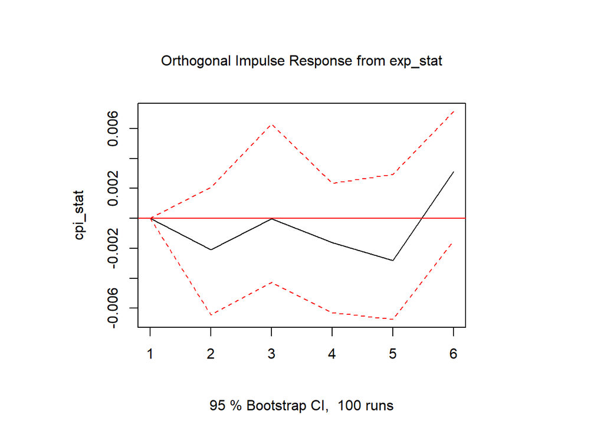

```r
irf(var, impulse ="exp_stat", response="cpi_stat", n.ahead=5) %>% plot()
```

We see the reaction is minimal, the model conceptually is not adequate.

## Question 4. Present both the ACF and PACF functions and their plots. Discuss their properties, similarities and differences and explain their uses when modelling ARMA and ARIMA models. Present an example of using these tools to fit a model on a simulated ARMA/ARIMA process.

### ACF

Given the auto-covariance of time series $x_t$ at lag $s$ is: $\gamma(s,t)=\sum^T_{t=s+1}(x_t-\bar{x})(x_{t-s}-\bar{x})$

The Auto-Correlation function is defined as the scaled auto-covariance: $\rho(s,t)=\frac{\sum^T_{t=s+1}(x_t-\bar{x})(x_{t-s}-\bar{x})}{\sum^T_{t=1}(x_t-\bar{x})}=\frac{\gamma(s,t)}{\sqrt{\gamma(s,s)\gamma(t,t)}}$

The denominator is the lag 0 covariance, lag 0 is time $t$, so it is the estimated variance of the time series. It measures the linear predictability of a stationary time series at time $t$ only using the values $x_s$ (value of the series at lag $s$). If through $\hat{x_t}=\beta_0+\beta_1x_s$ we can perfectly predict the values of the time series at time $t$, we have $\rho=1$ for $\beta_1>0$ (positive linear relationship) or $\rho=-1$ for $\beta_1<0$ (negative linear relationship).

This function to give reliable results must be used on weakly stationary data. What are the features of a **weakly** **stationary** series?

1. The mean of the series is stable over the finite length of the data series we observe. $\mathbb{E}[X_t]=\mathbb{E}[X_{t+s}]=\mu$
2. The covariance structure is stable over time. $\gamma(t,\tau)=cov(y_t, y_{t-\tau})=\mathbb{E}(y_t-\mu)(y_{t-\tau}-\mu)=\gamma(\tau)$ This means that that the auto-covariance only depends on the difference between time t and time s $\tau=t-s$.
3. We require that the variance of the series to be finite. $\mathbb{E}[|X_t|^2]<\infty$ Which as we previously defined answering question 4 is autocorrelation at lag 0. $\gamma(0)<\infty$

We can mathematically define it as: $corr(X_t,X_{t+h})=corr(X_{t+j}, X_{t+h+j})$ for all $j$.

For example a series which steadily increases/decreases will not have a stable mean, same situation for a series with seasonality where the mean will change depending on the season. If the above illustrated assumptions are not met then the estimate of the ACF is not correct.

### PACF

The Partial Auto-Correlation is the conditional correlation between prediction error (if the series is Gaussian). The partial autocorrelation at lag $s$ is the autocorrelation between $x+s$ and $x_t$ without considering the correlation with lags from $s-1$ to $1$.

$\alpha(s)=\frac{cov(x_{t+s}, x_t|x_{t+s-1},...,x_{t+1})}{\sqrt{var(x_{t+s}|x_{t+s-1},...,x_{t+1})var(x_{t}|x_{t+s-1},...,x_{t+1}))}}$ It is the correlation between $x_{t+s}$ and $x_t$. The linear dependence of ${x_{t+1},…,x_{t+s-1}}$ on $x_{t+s}$ and on $x_t$ is taken out.

### Similarities & Differences

- Both functions measure correlation with between a time series observations and lagged values. This of course with their own differences, given that PACF takes out the intermediate effects.
- The values of the two functions range from 1 to -1.
- In the ACF plot the autocorrelation observed propagates to later lags, because we are considering those correlations we do not consider in PACF.

### Use in modelling

We will name some general guidelines for the use of ACF/PACF in modelling. We remind the reader that both functions assume stationarity in the data.

PACF can be used to determine the order of the AR() in ARMA/ARIMA models, of the kind $(p,d,0)$.

- The lags in the ACF plot decay exponentially or in a sinusoidal way;
- The is a significant lag at time $p$ in the PACF plot, but no other significant signal after that.

If for example we have a PACF plot with only lag 1 being significant, then the appropriate choice would be AR(1). PACF plots are useful to determine whether our series is looking like it has not been differentiated enough, then the plot will show significant lags (most likely lag 1).

ACF instead suggests how many MA() terms are to be added to an ARIMA model of the form $(0,d,q)$ .

- The PACF is decaying in an exponential or sinusoidal way;
- There is significant lag at time $q$ in the ACF plot, and no other significant signal after that lag $q$.

If the correlogram cuts of at lag $k$ then the model most likely will need MA() of order $k$. MA() terms can compensate for a time series that has gone through to many rounds of differencing.

So we have said that MA() and AR() terms can counterbalance or compensate differencing, this tells us that ACF() and PACF() provide great insight but not necessarily they tell us the whole story.

### Example

Let’s consider a ARIMA(1,1,1) model, so a model which includes a AR(1) term, 1st order differencing and, a MA(1) term.

A full model can be written as: $y'_t=c+\phi_1 y'_{t-1}+...+\phi_p y'_{t-p}+\theta_1 \epsilon_{t-1} +...+ \theta_q \epsilon_{t-q}+\epsilon_t$ .

Where $q$ if the order of the Moving Average part and $p$ is the order of the Autoregressive part of the model. $c$ is a constant in this case.

We write then the considered model:

$y'_t=c+\phi_1 y'_{t-1}+ \theta_1 \epsilon_{t-1}+\epsilon_t$ where $y'_t$ is the differentiated series $y'_t=y_t-y_{t-1}$.

We re-write it in the backshift notation: $(1-\phi_1 B)(1-B)y_t=c+(1+\theta_1B)\epsilon_t$

- The $(1-\phi_1 B)$ operator represents the inclusion of a AR(1) term;
- The $(1+\theta_1B)$ operator represents the inclusion of a MA(1) term. We can see the $\theta_1$ term as a $1-\alpha$ term in a SES model, if $\theta_1=1$ then $\alpha=0$ (the smoothing parameter, the one controlling how the weights decrease), meaning the model is constant, you are considering all historical observations.
- $(1-B)$ represents the inclusion of a 1st order differentiation in the series.

If $\phi_1$ is very close to 1 the factor $(1-\phi_1 B)$ will be very similar to $(1-B)$, therefore almost mimicking a differentiation round. If $\theta_1$ is very close to one than the factor $(1-\theta_1 B)$ will be very close to $(1-B)$, being the MA() factor on the other side of the equation it would almost cancel out the differencing term. Therefore, when modelling ARIMA models we should be mindful of redundant p,q terms, of course looking that their coefficients.

### Example

#### ARIMA(p,d,q)

We simulate an ARIMA(1,d,1) model. We modify the function presented in class during TP7 for an ARMA model, we do not consider a constant.

- $c=0$ and $d=0$ the long term forecast will go to zero;
- $c=0$ and $d=1$ the long term forecast will go to a non-zero constant.
- $\phi_1+\theta_1\neq0$

```r
# Replicability


# Initialisation of function
arima_model <- function(phi, d, theta, n = 100) {                  # the inputs are not p and q but phi and theta
  y<-numeric(n)                                                    # empty vector y
  y_model <- numeric(n)                                            # empty final vector y
  e <- rnorm(n)                                                    # normally distributed error vector
  if (d == 0) {                                                    # if d is set to 0
    for (i in 2:n) {                                               # we do not perform differencing
      y_model[i] <- phi * y[i - 1] + theta * e[i - 1] + e[i]
    }
  } else {                                                         # otherwise we differentiate
    y_diff <- numeric(n)                                           # empty vector to store the differentiated series
    for (i in (d + 1):n) {
      y_diff[i] <- y[i] - y[i - d]
      for (j in 1:d) {
        y_diff[i] <- y_diff[i] - y_diff[i - j]                     # nested loop to perform differencing if d>1
      }
      y_model[i] <- phi * y_diff[i - 1] + theta * e[i - 1] + e[i]
    }
  }

  tsibble(idx = seq_len(n), y = y_model, index = idx)              # store the model in a tsibble format
  #print(y_diff) uncomment this only if d>0
}
```

When selecting the $phi$ and $theta$ there are some rules we should be take into consideration. Usually this is done automatically by the functions fitting the model, but since we are the ones inputting these values now we need to consider them.

- $-1<\phi_1<1$
- $-1<\theta_1<1$

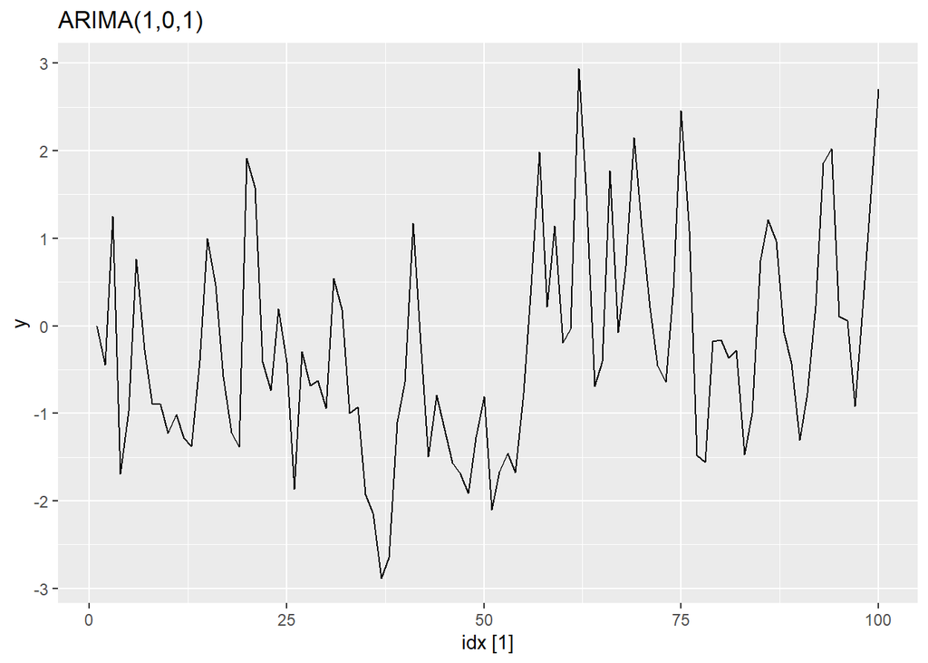

```r
#Replicability
set.seed(1234)

# ARIMA(1,0,1) model
arima_model(0.6,0,0.6)%>%autoplot()+ggtitle("ARIMA(1,0,1)")
```

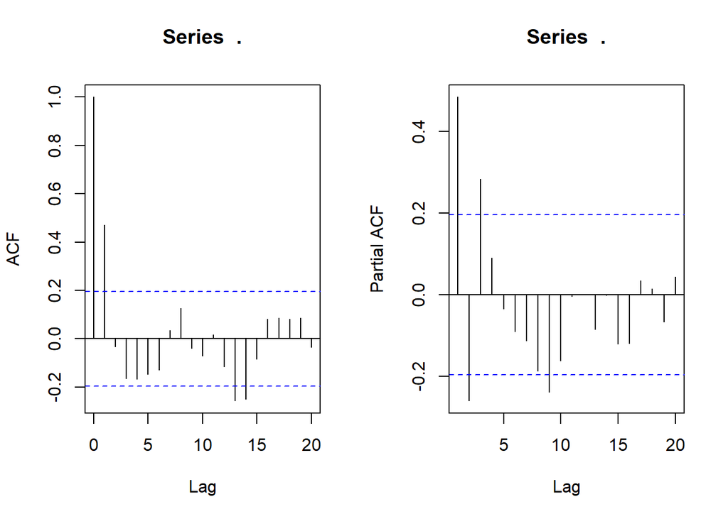

```r
par(mfrow = c(1, 2))
arima_model(0.6,0,0.6)%>%acf()
arima_model(0.6,0,0.6)%>%pacf()
```

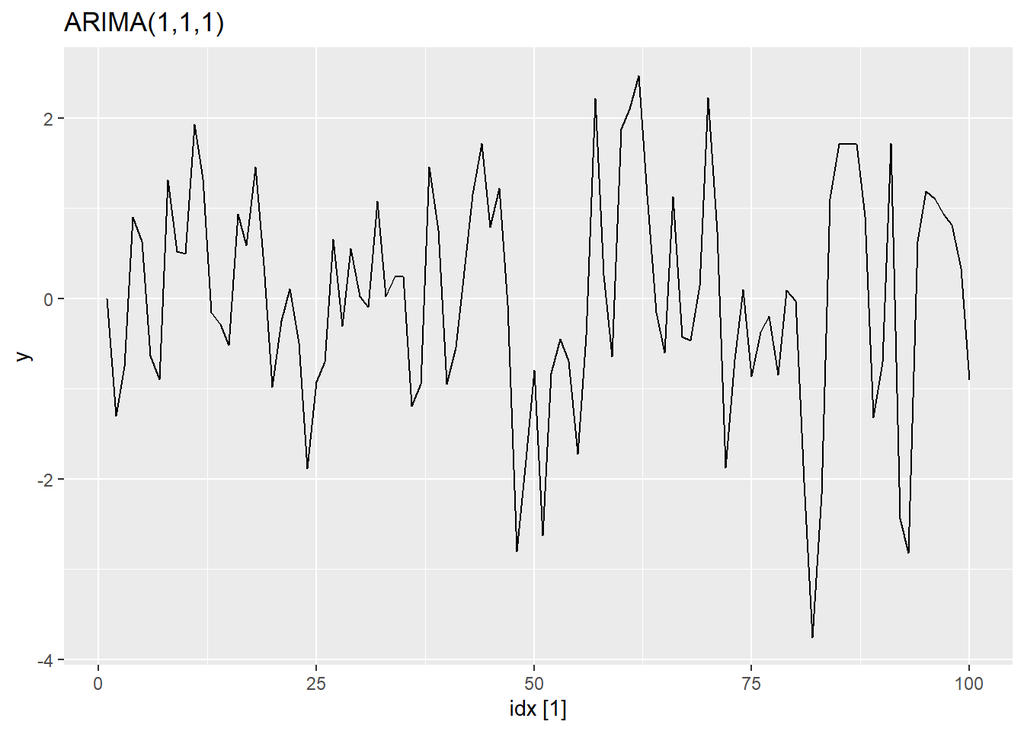

```r
#ARIMA(1,1,1) model
arima_model(0.6,1,0.6)%>%autoplot()+ggtitle("ARIMA(1,1,1)")
```

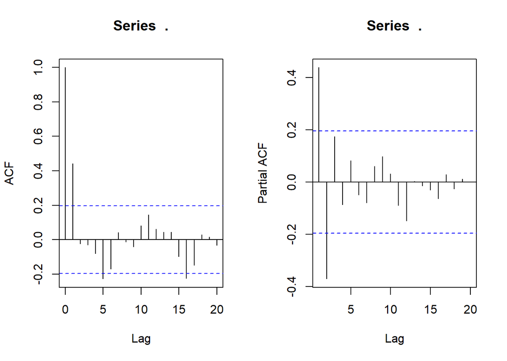

```r
par(mfrow = c(1, 2))
arima_model(0.6,1,0.6)%>%acf()
arima_model(0.6,1,0.6)%>%pacf()
```

We try with higher $\phi$ and $\theta$ values (closer to 1), to gain insight into the AR() and MA() redundancy and effect on differentiation:

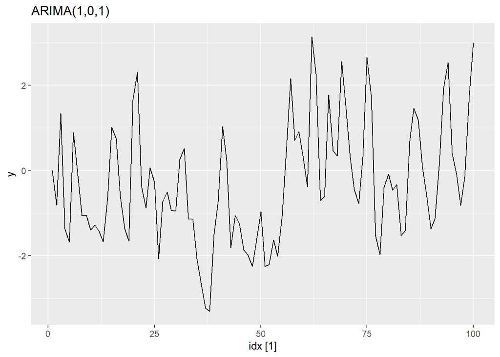

```r
set.seed(1234)

#ARIMA(1,0,1)
arima_model(0.9,0,0.9)%>%autoplot()+ggtitle("ARIMA(1,0,1)")
```

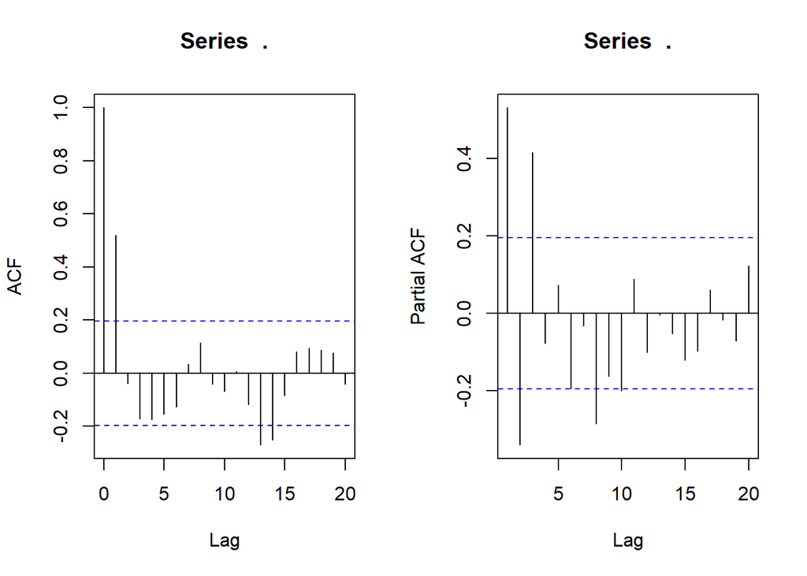

```r
par(mfrow = c(1, 2))
arima_model(0.9,0,0.9)%>%acf()
arima_model(0.9,0,0.9)%>%pacf()
```

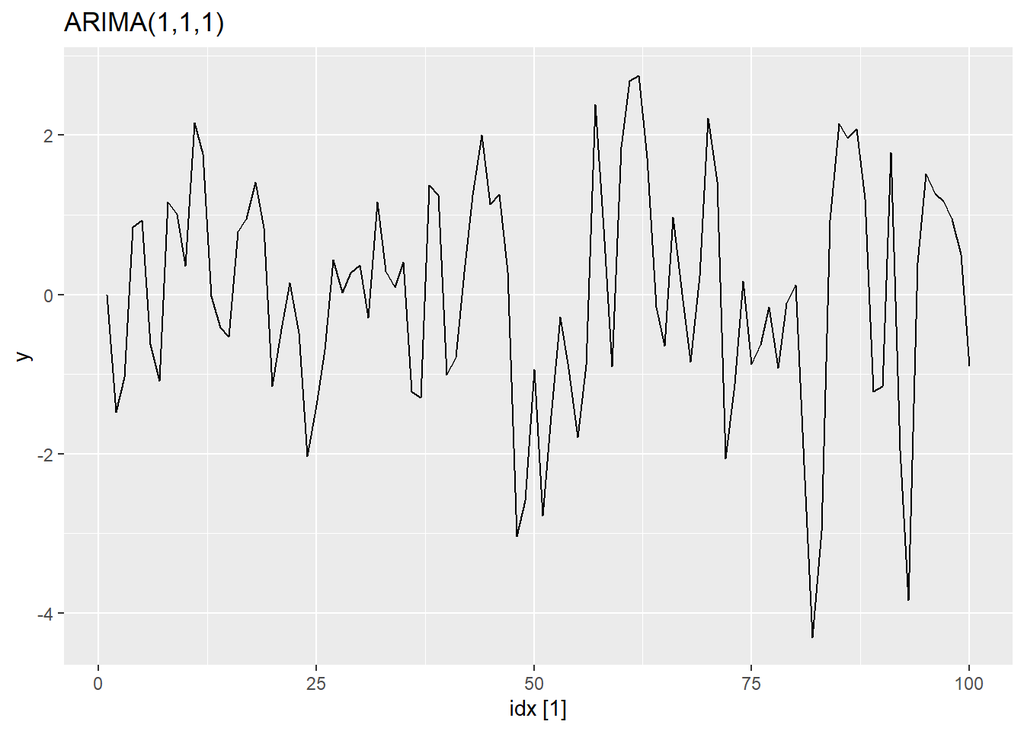

```r
# ARIMA(1,1,1)
arima_model(0.9,1,0.9)%>%autoplot()+ggtitle("ARIMA(1,1,1)")
```

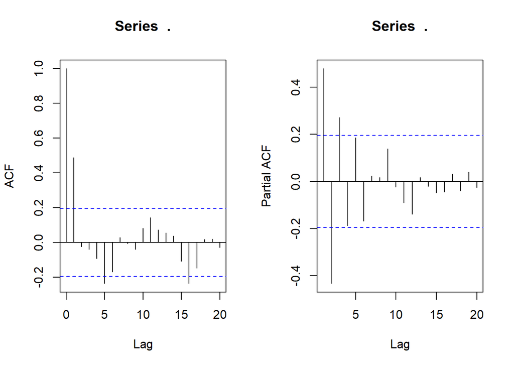

```r
par(mfrow = c(1, 2))
arima_model(0.9,1,0.9)%>%acf()
arima_model(0.9,1,0.9)%>%pacf()
```

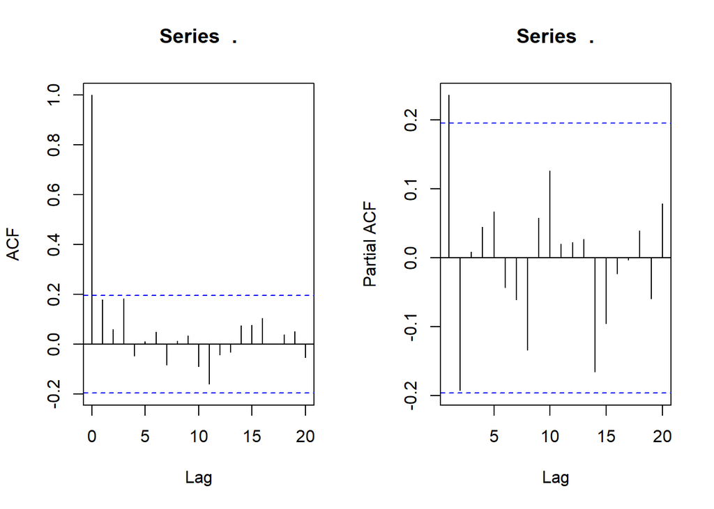

```r
par(mfrow = c(1, 2))
arima_model(0.9,1,0.3)%>%acf()
arima_model(0.9,1,0.3)%>%pacf()
```

#### AR() and MA() processes

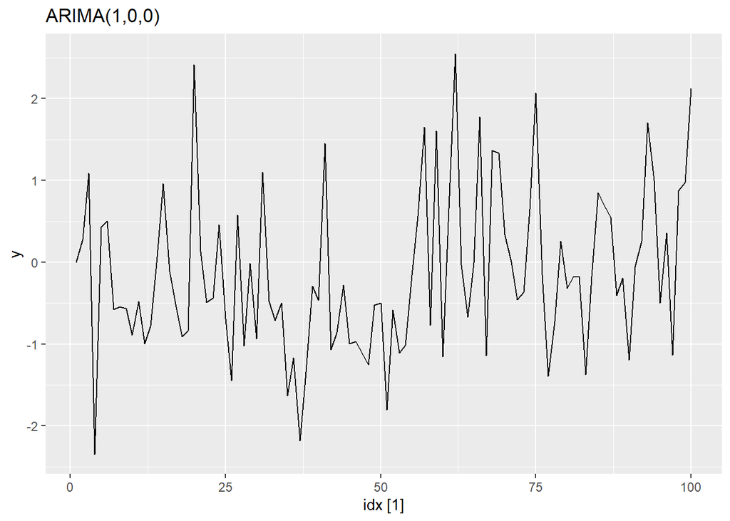

```r
set.seed(1234)

#ARIMA(1,0,0)
arima_model(0.2,0,0)%>%autoplot()+ggtitle("ARIMA(1,0,0)")
```

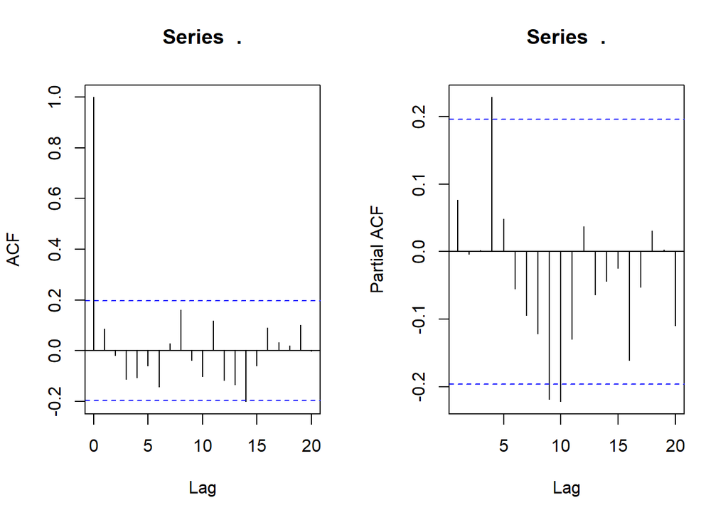

```r
par(mfrow = c(1, 2))
arima_model(0.2,0,0)%>%acf()
arima_model(0.2,0,0)%>%pacf()
```

We now try to fit a MA(2) with small enough $\theta_1$ values:

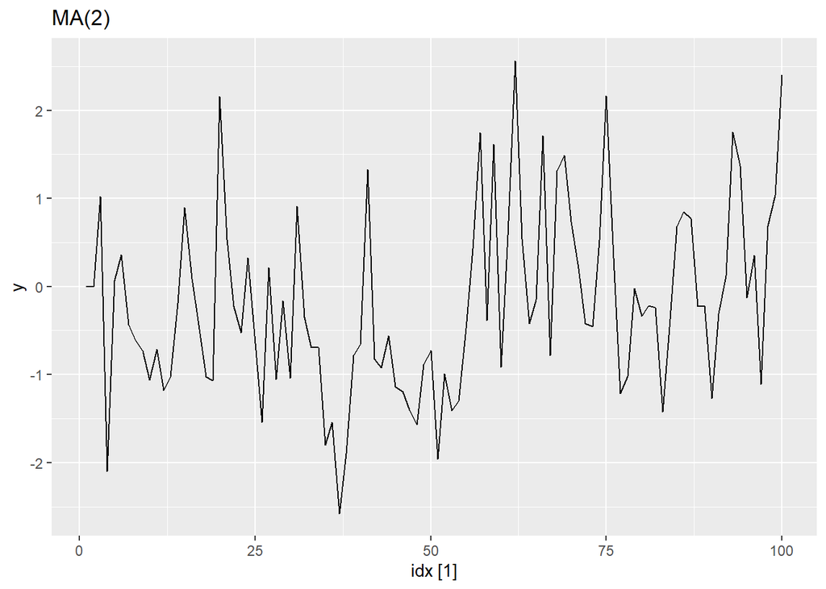

```r
set.seed(1234)

# Moving Average model function
ma2 <- function(theta1, theta2, n = 100L) {
  y <- numeric(n)
  e <- rnorm(n)
  for (i in 3:n) {
    y[i] <- theta1 * e[i - 1] +theta2 * e[i - 2] + e[i]
  }
  tsibble(idx = seq_len(n), y = y, index = idx)
}

ma2(0.2,0.1)%>%autoplot()+ggtitle("MA(2)")
```